# Lab 10: Filtering Data

## Pick a dataset

Pick a dataset (feel free to delete the others from the Rmd file if you would like), and work on the instructions in the next section.

## Instructions

This lab is similar to the last. You’ll pick a dataset and then generate an analysis of that data using data visualizations. The difference here is that instead of a single plot, I would like you to construct 3-4 plots that together tell a linear story. Each plot should be separated by a sentence or two describing what the viewer should take away from the plot. Try to keep the plots similar in some way; perhaps each simply highlights a different subset of the data but has the same underlying layers.

Notice that each of the datasets for today are larger than you will probably be able to use. You will need to filter the data to a particular team, year, subset of curse words. You may further filter the data to highlight an even smaller subset of the data within each plot.

## Plots

This plot shows the total number of swear words used in each of the Tarantino Films.

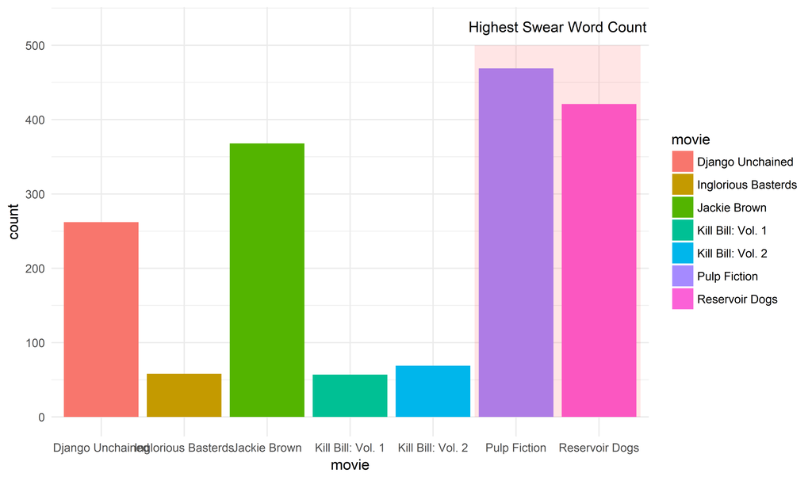

```
## # A tibble: 421 x 4
##    movie          type  word     minutes_in
##    <chr>          <chr> <chr>         <dbl>
##  1 Reservoir Dogs word  dick          0.400
##  2 Reservoir Dogs word  dicks         0.430
##  3 Reservoir Dogs word  fucked        0.550
##  4 Reservoir Dogs word  fucking       0.610
##  5 Reservoir Dogs word  bullshit      0.610
##  6 Reservoir Dogs word  fuck          0.660
##  7 Reservoir Dogs word  shit          0.900
##  8 Reservoir Dogs word  fuck          1.43
##  9 Reservoir Dogs word  dicks         1.56
## 10 Reservoir Dogs word  fuck          1.66
## # ... with 411 more rows
```

This bar graph shows the total number of each swear word throughout the film “Reservoir Dogs.”

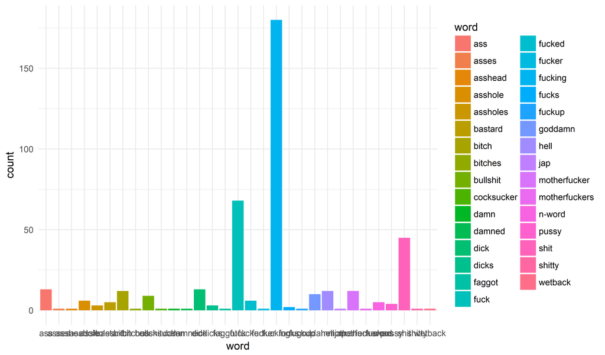

```
## # A tibble: 469 x 4
##    movie        type  word    minutes_in
##    <chr>        <chr> <chr>        <dbl>
##  1 Pulp Fiction word  shit         0.520
##  2 Pulp Fiction word  fucking      0.820
##  3 Pulp Fiction word  fuck         1.37
##  4 Pulp Fiction word  fucking      1.62
##  5 Pulp Fiction word  fucking      1.73
##  6 Pulp Fiction word  fucking      1.77
##  7 Pulp Fiction word  fucking      2.18
##  8 Pulp Fiction word  fuck         2.22
##  9 Pulp Fiction word  gook         2.28
## 10 Pulp Fiction word  fuckers      2.28
## # ... with 459 more rows
```

This bar graph depicts the total number of each swear word throughout the film “Pulp Fiction.”

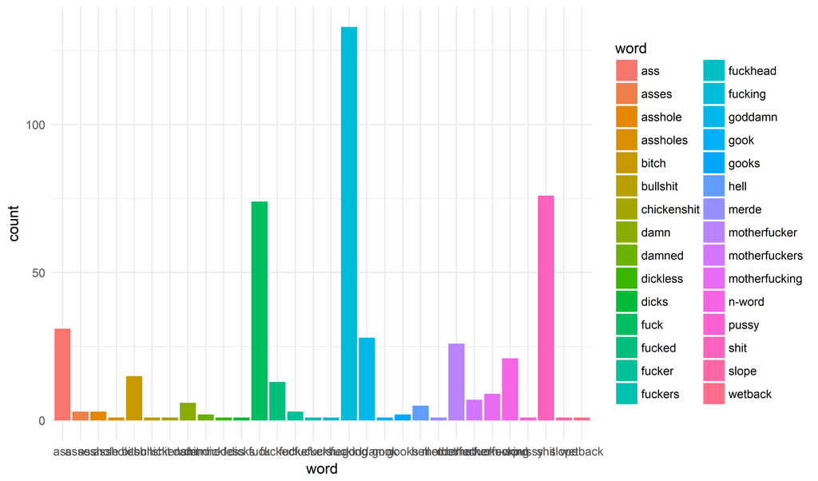

```
## # A tibble: 890 x 4
##    movie          type  word     minutes_in
##    <chr>          <chr> <chr>         <dbl>
##  1 Reservoir Dogs word  dick          0.400
##  2 Reservoir Dogs word  dicks         0.430
##  3 Reservoir Dogs word  fucked        0.550
##  4 Reservoir Dogs word  fucking       0.610
##  5 Reservoir Dogs word  bullshit      0.610
##  6 Reservoir Dogs word  fuck          0.660
##  7 Reservoir Dogs word  shit          0.900
##  8 Reservoir Dogs word  fuck          1.43
##  9 Reservoir Dogs word  dicks         1.56
## 10 Reservoir Dogs word  fuck          1.66
## # ... with 880 more rows
```

This graph shows the total number of swear words used in both the films “Pulp Fiction” and “Reservoir Dogs.”

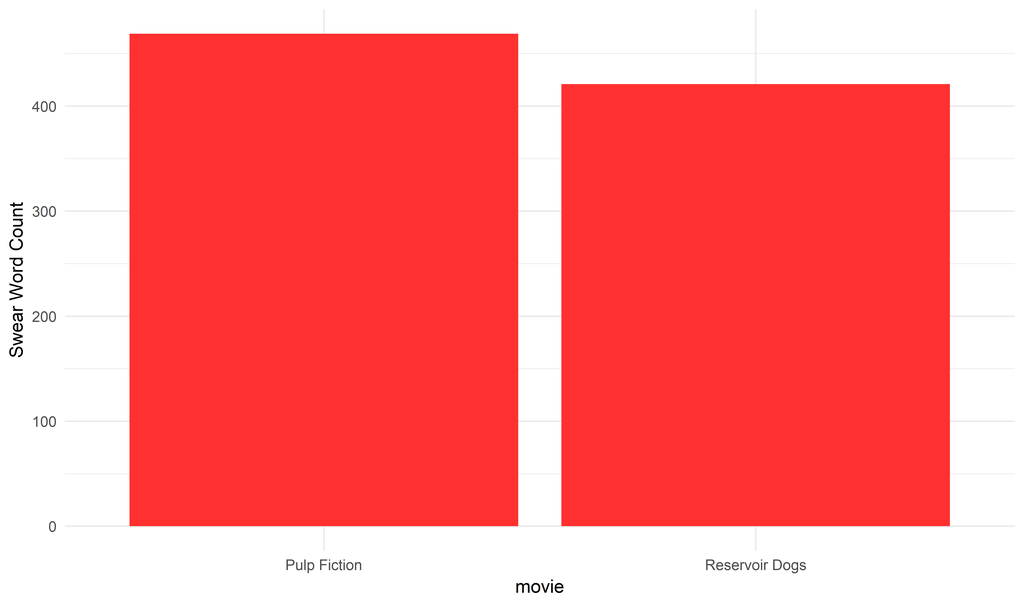

```
## # A tibble: 46 x 4
##    movie          type  word          minutes_in
##    <chr>          <chr> <chr>              <dbl>
##  1 Reservoir Dogs word  motherfucker        1.83
##  2 Reservoir Dogs word  motherfucker        3.93
##  3 Reservoir Dogs word  motherfucker        3.98
##  4 Reservoir Dogs word  motherfuckers      16.6
##  5 Reservoir Dogs word  motherfucker       22.5
##  6 Reservoir Dogs word  motherfucker       42.6
##  7 Reservoir Dogs word  motherfucker       50.9
##  8 Reservoir Dogs word  motherfucker       64.3
##  9 Reservoir Dogs word  motherfucker       65.2
## 10 Reservoir Dogs word  motherfucker       65.8
## # ... with 36 more rows
```

This bar graph shows the total number of time that the words “motherfucker” and “motherfuckers” were used in the films “Pulp Fiction” and “Reservoir Dogs.”

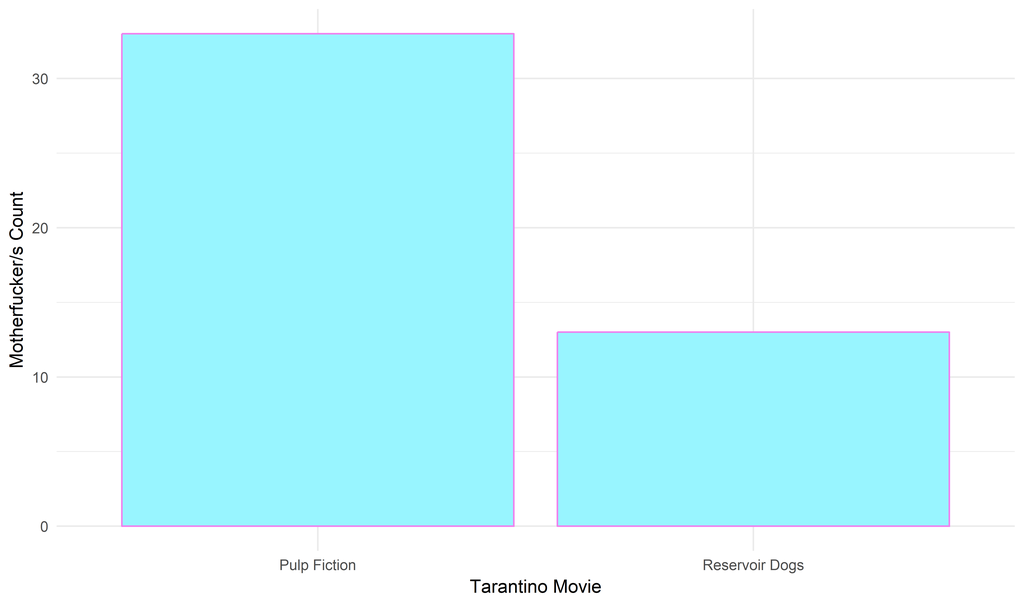

## Analysis

In all of the Tarantino films, the highest number of swear words were used in “Pulp Fiction” and “Reservoir Dogs.” It is clear that the difference in the total number of swear words used in both movies was not large, therefore I observed how much of the total count was represented by “motherfucker” and “motherfuckers” in the films. The frequency of those two words was much greater in “Pulp Fiction,” suggesting that various other swear words were used more often in “Reservoir Dogs” that make up for the lack of “motherfucker” and “motherfuckers” in “Reservoir Dogs” that drew the total swear word count closer to that of “Pulp Fiction.”